# Лабораторная 8

Модель конкуренции двух фирм

Шалыгин Г. Э.

Российский университет дружбы народов, Москва, Россия

# Информация

## Докладчик

- Шалыгин Георгий Эдуардович
- студент НФИ-02-20
- Российский университет дружбы народов

# Вводная часть

## Актуальность

- Математическое моделирование - важная часть компетенции в образовательном треке НФИ

## Цели и задачи

- Изучить построение математической модели конкуренции двух фирм..
- Задачи:
  - Постройте графики изменения оборотных средств фирмы 1 и фирмы 2 без учета постоянных издержек и с веденной нормировкой для случая 1.
  - Постройте графики изменения оборотных средств фирмы 1 и фирмы 2 без учета постоянных издержек и с веденной нормировкой для случая 2.

## Материалы и методы

- Процессор `pandoc` для входного формата Markdown
- Результирующие форматы
  - `pdf`
  - `html`
- Автоматизация процесса создания: `Makefile`
- Компилятор Julia
- OpenModelica

## Содержание исследования

Рассмотрим две фирмы, производящие взаимозаменяемые товары одинакового качества и находящиеся в одной рыночной нише. Считаем, что в рамках нашей модели конкурентная борьба ведётся только рыночными методами. То есть, конкуренты могут влиять на противника путем изменения параметров своего производства: себестоимость, время цикла, но не могут прямо вмешиваться в ситуацию на рынке («назначать» цену или влиять на потребителей каким-либо иным способом.) Будем считать, что постоянные издержки пренебрежимо малы, и в модели учитывать не будем. В этом случае динамика изменения объемов продаж фирмы 1 и фирмы 2 описывается следующей системой уравнений:

## Содержание исследования

$$\dfrac{dM_1}{d\theta} = M_1 - \frac{b}{c_1}M_1M_2 - \frac{a_1}{c_1}M_1^2$$

$$\dfrac{dM_2}{d\theta} = \frac{c_2}{c_1}M_1 - \frac{b}{c_1}M_1M_2 -
\frac{a_2}{c_1}M_2^2$$

## Содержание исследования

Рассмотрим модель, когда, помимо экономического фактора влияния (изменение себестоимости, производственного цикла, использование кредита и т.п.), используются еще и социально-психологические факторы – формирование общественного предпочтения одного товара другому, не зависимо от их качества и цены. В этом случае взаимодействие двух фирм будет зависеть друг от друга, соответственно коэффициент перед *M*<sub>1</sub>*M*<sub>2</sub> будет отличаться. Пусть в рамках рассматриваемой модели динамика изменения объемов продаж фирмы 1 и фирмы 2 описывается следующей системой уравнений:

## Содержание исследования

$$\dfrac{dM_1}{d\theta} = M_1 - (\frac{b}{c_1}+0.00017)M_1M_2 -
\frac{a_1}{c_1}M_1^2$$

$$\dfrac{dM_2}{d\theta} = \frac{c_2}{c_1}M_1 - \frac{b}{c_1}M_1M_2 -
\frac{a_2}{c_1}M_2^2$$

# Результаты

## Модель 1

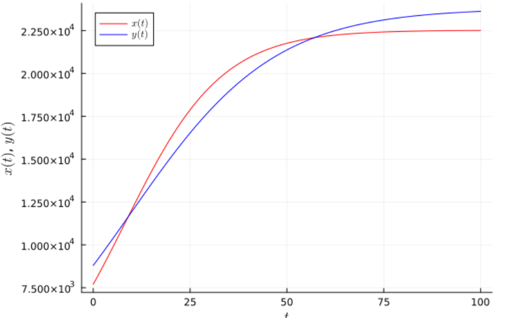

модель 1

## Модель 2

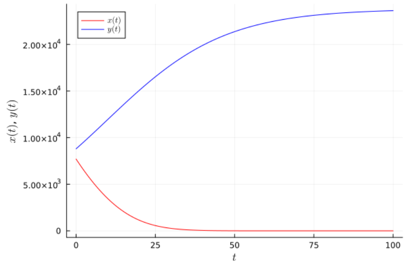

модель 2

# Вывод

В итоге была рассмотрена простейшая модель конкуренции двух фирм . С использованием Julia и OpenModelica построены графики изменения капитала.